# Homework_02

Marco Zullich

18 April 2019

# TH-1

Given a M.C. with transition matrix

$$P=
\left[
\begin{matrix}
0.5 & 0.5 & 0 & 0 & 0 & 0 \\
0.25 & 0.5 & 0.25 & 0 & 0 & 0 \\
0 & 0.25 & 0.5 & 0.25 & 0 & 0 \\
0 & 0 & 0.25 & 0.5 & 0.25 & 0 \\
0 & 0 & 0 & 0.25 & 0.5 & 0.25 \\
0 & 0 & 0 & 0 & 0.5 & 0.5
\end{matrix}
\right]$$
Show that the stationary distribution $\pi$ is equal to $(0.1, 0.2, 0.2, 0.2, 0.2, 0.1)$.

Since the stationary distribution is such that $\pi\cdot P = \pi$, we can express it as a linear system where the unknowns are the components of the vector $\pi$. That’s to say:
$$\begin{cases}
0.5 \cdot \pi_1 + 0.25 \cdot \pi_2 = \pi_1 \\
0.5\cdot \pi_1 + 0.5 \cdot \pi_2 + 0.25 \cdot \pi_3 = \pi_2 \\
0.25\cdot \pi_2 + 0.5\cdot\pi_3+0.25\cdot\pi_4 = \pi_3 \\
0.25\cdot \pi_3 + 0.5\cdot\pi_4+0.25\cdot\pi_5 = \pi_4 \\
0.25\cdot \pi_4 + 0.5 \cdot \pi_5 + 0.5 \cdot \pi_6 = \pi_5 \\
0.25 \cdot \pi_5 + 0.5 \cdot \pi_6 = \pi_6
\end{cases}$$
By moving the unknowns to the right hand side of the equations:

We may rewrite it as
$$\overbrace{
\left[
\begin{matrix}
-0.5 & 0.25 & 0 & 0 & 0 & 0 \\
0.5 & -0.5 & 0.25 & 0 & 0 & 0 \\
0 & 0.25 & -0.5 & 0.25 & 0 & 0 \\
0 & 0 & 0.25 & -0.5 & 0.25 & 0 \\
0 & 0 & 0 & 0.25 & -0.5 & 0.5 \\
0 & 0 & 0 & 0 & 0.25 & -0.5
\end{matrix}
\right]
}^{P^*}
\cdot \pi = 0_6$$
Where with $0_6$ we indicate the null vector with dimension 6.

The system, though, is singular, we can easily check by calculating the determinant of $P^*$:

```r
P_star = matrix(c(-.5, .25, rep(0,4),
                  .5, -.5, .25, rep(0,3),
                  0, .25, -.5, .25, rep(0,2),
                  rep(0,2), .25, -.5, .25, 0,
                  rep(0,3), .25, -.5, .5,
                  rep(0,4), .25, -.5), nrow = 6, byrow = T)
det(P_star)
```

```
## [1] 0
```

We may then replace the final equation of the system with the constraint
$$||\pi||_1 = 1$$
Were $||\cdot||_1$ denotes the L1 norm.

The system then becomes
$$\begin{cases}
-0.5 \cdot \pi_1 + 0.25 \cdot \pi_2 = 0 \\
0.5\cdot \pi_1 -0.5 \cdot \pi_2 + 0.25 \cdot \pi_3 = 0 \\
0.25\cdot \pi_2 -0.5\cdot\pi_3+0.25\cdot\pi_4 = 0 \\
0.25\cdot \pi_3 -0.5\cdot\pi_4+0.25\cdot\pi_5 = 0 \\
0.25\cdot \pi_4 -0.5 \cdot \pi_5 + 0.5 \cdot \pi_6 = 0 \\
\pi_1 + ... + \pi_6 = 1
\end{cases}$$
Or, equivalently,
$$\overbrace{
\left[
\begin{matrix}
-0.5 & 0.25 & 0 & 0 & 0 & 0 \\
0.5 & -0.5 & 0.25 & 0 & 0 & 0 \\
0 & 0.25 & -0.5 & 0.25 & 0 & 0 \\
0 & 0 & 0.25 & -0.5 & 0.25 & 0 \\
0 & 0 & 0 & 0.25 & -0.5 & 0.5 \\
1 & 1 & 1 & 1 & 1 & 1
\end{matrix}
\right]
}^{Q}
\cdot
\left[
\begin{matrix}
\pi_1 \\ \pi_2 \\ \pi_3 \\ \pi_4 \\ \pi_5 \\ \pi_6
\end{matrix}
\right]
=
\left[
\begin{matrix}
0 \\ 0 \\ 0 \\ 0 \\ 0 \\ 1
\end{matrix}
\right]$$

The system of equation can be easily solved using R:

```r
Q = matrix(c(-.5,.25,0,0,0,0,
             .5,-.5,.25,0,0,0,
             0,.25,-.5,.25,0,0,
             0,0,.25,-.5,.25,0,
             0,0,0,.25,-.5,.5,
             1,1,1,1,1,1),
           nrow = 6, ncol = 6, byrow = T)
solve(Q, c(rep(0, 5),1))
```

```
## [1] 0.1 0.2 0.2 0.2 0.2 0.1
```

Which is the solution, or, the stationary distribution to which our Markov Chain converges.

# TH-2

We are given the prior distributions for our parameters $\theta, N$:

$$\theta \sim Beta(\alpha, \beta) \\
N \sim Poi(\lambda)$$
Since the number of seeded eggs (identified by the random variable $X$) models a situation in which we have a total number of eggs, each with equal and independent probability of being seeded, we can model it using a binomial distribution whose parameters are $N$ (number of total eggs deposited) and $\theta$ (probability of an egg being seeded). The binomial distribution is obtained only when those two parameters are fixed (hence are r.v. no more):

$$X|N=n,\theta=t \sim Bi(N,t)$$
This is the likelihood and it solves one point of the full conditionals search.

To find the other two full conditionals, we’ll need to write the posterior:

For the final full conditional, instead, we have that:

$$\pi(N|\theta = t, X = x) = \binom{N}{x} \frac{\lambda^N}{N!} \cdot (1-t)^{N-x} = \frac{{N!}}{x!(N-x)!} \frac{\lambda^N}{{N!}}(1-t)^{N-x} \propto \frac{\lambda^N \lambda^{-x}}{(N-x)!}(1-t)^{N-x} \\ \propto \frac{[\lambda(1-t)]^{N-x}}{(N-x)!}e^{-\lambda} \Longrightarrow N-x|(\theta=t\wedge X=x) \sim Poisson(\lambda(1-t))$$

Before applying the Gibbs sampler, we need to specify a value for our coefficients $\alpha, \ \beta,\ \lambda$.

We might say, for example, that:

$$\lambda=5 \ \longrightarrow N\sim Poi(5) \\
\alpha=2, \beta=6 \longrightarrow \theta \sim Beta(2,6)$$
Graphical representation of the prior:

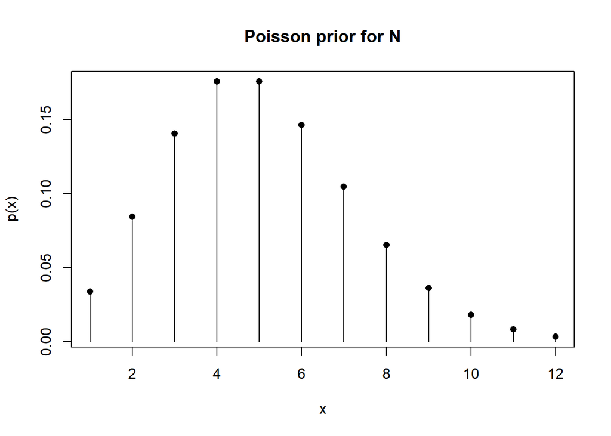

```r
plot(1:12,dpois(1:12,5), type='h', xlab="x", ylab="p(x)", main="Poisson prior for N")
points(1:12,dpois(1:12,5), pch=16)
```

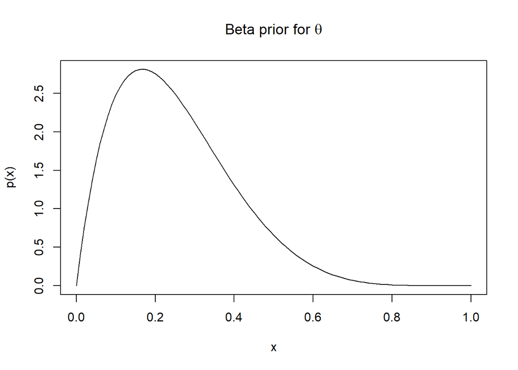

```r
curve(dbeta(x,2,6), xlab="x", ylab="p(x)", main=expression(paste("Beta prior for ",theta)))
```

Now we can then code our Gibbs sampler:

```r
gibbs = function(nsim){
  #intialization of vectors to store solution
  x = rep(0, nsim)
  theta = rep(0, nsim)
  n = rep(0, nsim)

  #initialization of parameters
  #x starts at 0
  theta[1] = .25
  n[1] = 5

  #main cycle
  for(s in 2:nsim){
    #use previous value of n, theta to obtain current x
    x[s] = rbinom(1, n[s-1], theta[s-1])
    #use current x, previous n to obtain current theta
    theta[s] = rbeta(1,2+x[s],6+n[s-1]-x[s])
    #use both current x, theta to obtain current n
    #since we know full contidional on N-x, get N-x then sum current x
    n[s] = rpois(1,5*(1-theta[s])) + x[s]
  }

  return(list(x=x, theta=theta, n=n))

}
```

and run it:

```r
set.seed(0) #to ensure reproducibility
params = gibbs(10000)
```

We may now plot the simulated distribution of x:

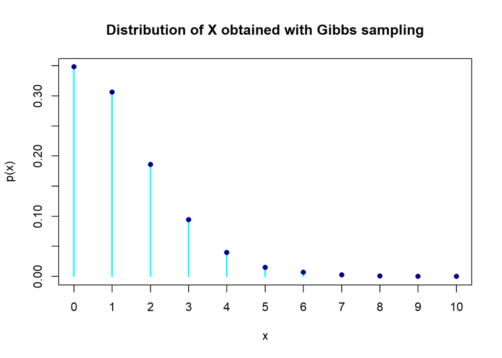

```r
x=params$x
plot(table(x)/length(x), type="h", lwd=2, col="cyan", main="Distribution of X obtained with Gibbs sampling", ylab="p(x)")
points(0:max(x),table(x)/length(x), pch=16, col="blue4")
```

$X$ is a compound distribution depending upon two other random variables which are $N$ and $\theta$.

$X|\theta=t,N=n$ is a binomial distribution with parameters $n,t$, hence its mean is $nt$; the mean of $X$ is the same of the conditioned form, where $n$ and $t$ are replaced by $E(N), E(\theta)$:

$$E(X)=E(N)\cdot E(\theta)$$

The mean for our simulated `x` is:

```r
mean(x)
```

```
## [1] 1.2643
```

While the theoretical value is

```r
mean(params$n)*mean(params$theta)
```

```
## [1] 1.26151
```

The two values are pretty close to each other.

The variance for compound r.v.’s is higher than the variance of the conditioned r.v.:
$$V(X) = E[V(X|N=n,\theta=t)] + V[E(N,\theta)] = E(N)\cdot E(\theta)\cdot (1-E(\theta)) + V(N\theta)$$

```r
var(x)
```

```
## [1] 1.765422
```

```r
mean(params$n)*mean(params$theta)*(1-mean(params$theta)) + var(params$theta*params$n)
```

```
## [1] 1.878378
```

## Verify that the simulated conditional distribution of $\theta$ given $N=\hat{n}$ and $X=\hat{x}$, where $\hat{n}$ and $\hat{x}$ are posterior estimates, corresponds with the theoretical one

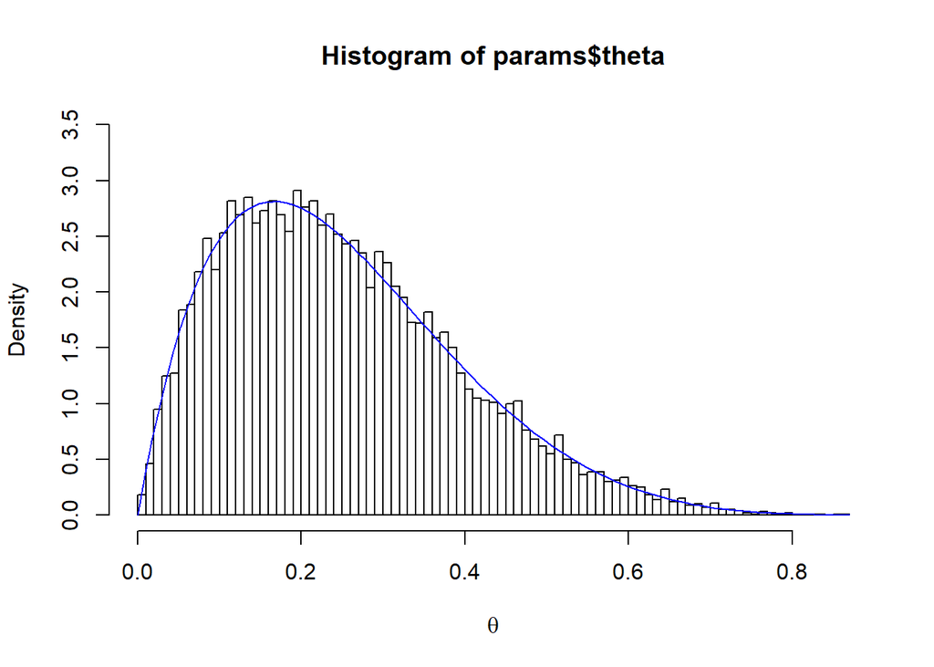

```r
hist(params$theta, breaks=100, prob=T, xlab=expression(theta), ylim=c(0,3.5))
curve(dbeta(x,2,6),add=T,col="blue")
```

# MCR-1

## Re-create graphs from Figure 6.7 (page 184)

First, we need to create the Metropolis-Hastings routine for the example (estimate a $N(0,1)$ where the proposal will be generated by offsetting the previous value of the chain by a random value drawn from a $U(-\delta,\delta)$, where $\delta$ is a hyperparameter.

```r
metro_hastings_N_unif = function(nsim, delta){
  x = rep(0, nsim)
  acc_values = 1

  #Let initlialization value be 0.

  for(s in 2:nsim){
    proposal = x[s-1] + runif(1, -delta, delta)
    accept_prob = min(1, exp((x[s-1]^2-proposal^2)/2))
    u = runif(1)
    if(u<accept_prob){
      x[s] = proposal
      acc_values = acc_values + 1
    }else{
      x[s] = x[s-1]
    }
  }

  acc_rate = acc_values/nsim

  return(list(x=x, acc_rate=acc_rate))
}
```

The `nsim` (number of simulations) is fixed at 5000, we reproduce the example by using three values for $delta$: 0.1, 1, 10:

```r
set.seed(100)
nsim = 5000
simulations = list(
  sim1 = metro_hastings_N_unif(nsim, .1),
  sim2 = metro_hastings_N_unif(nsim, 1),
  sim3 = metro_hastings_N_unif(nsim, 10)
)
```

Then we can reproduce the plot from the book. For sake of readability, we’ll produce them in triplets instead of all-at-once.

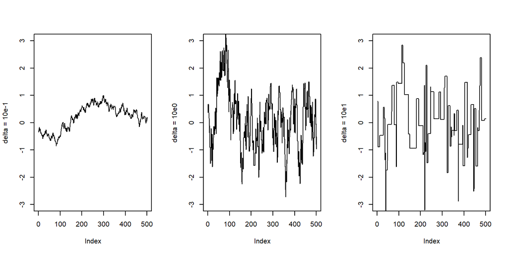

```r
par(mfrow=c(1,3))

#traceplots - only last 500 iterations (like in book)
for(i in 1:3)
   plot(simulations[[i]]$x[4500:5000], type='l', ylab = paste0("delta = 10e",i-2), ylim=c(-3,3))
```

Note: in order to better compare the three chains, we fixed the `ylim` attribute within `plot`: from here we can see how little exploration the first chain ($\delta=0.1$); the last chain ($\delta=10$) instead does a lot of exploitation (many horizontal lines in the graph, which implies that the acceptance rate is very low). Those issues may be better understood within the histograms below:

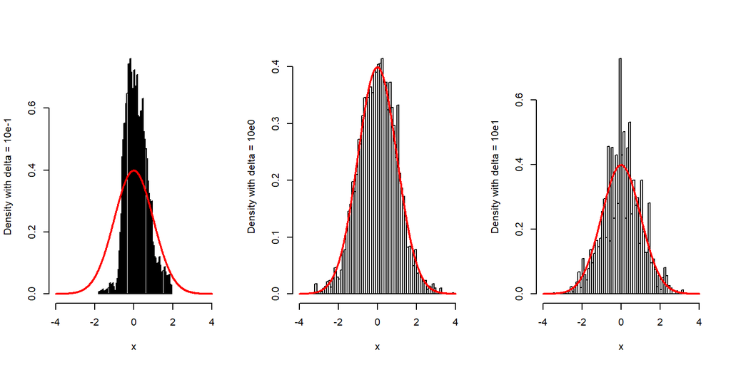

```r
par(mfrow=c(1,3))

#histograms
for(i in 1:3){
  hist(simulations[[i]]$x, breaks=100, main="", probability = T, ylab = paste0("Density with delta = 10e",i-2), xlim = c(-4,4), xlab = "x")
  lines(seq(-4,4, by=0.01), dnorm(seq(-4,4, by=0.01)),type="l", col="red", lwd=2)
}
```

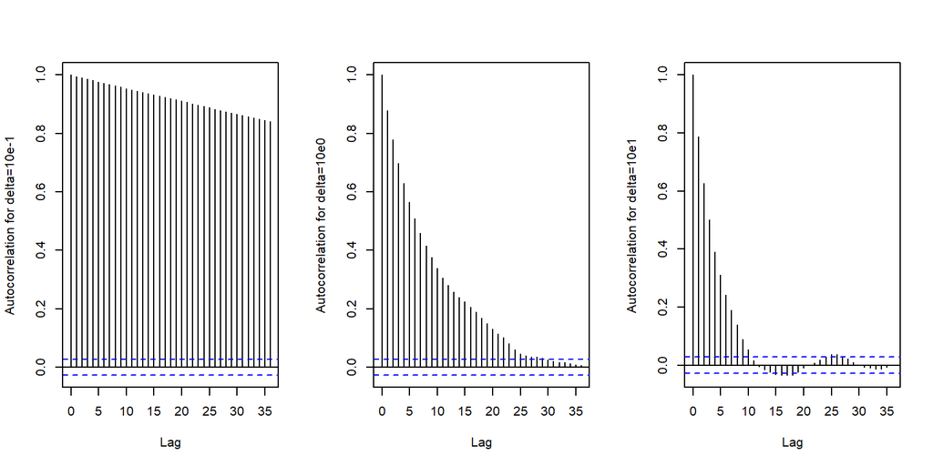

```r
par(mfrow=c(1,3))

#autocorrelation
for(i in 1:3)
  acf(simulations[[i]]$x, ylab=paste0("Autocorrelation for delta=10e",i-2), main="")
```

Sticking to autocovariance, we’ll repeat the simulations, this time exploring for other values of $\delta$. Given that 0.1 represents a very bad choice (see chart above), we’ll start with values closer to 1:

```r
set.seed(100)
deltas = seq(.5, 5, .5)
simluations2 = matrix(0, nrow=nsim, ncol=length(deltas))
for(d in 1:length(deltas)){
  simluations2[,d] = metro_hastings_N_unif(nsim, d)$x
}
```

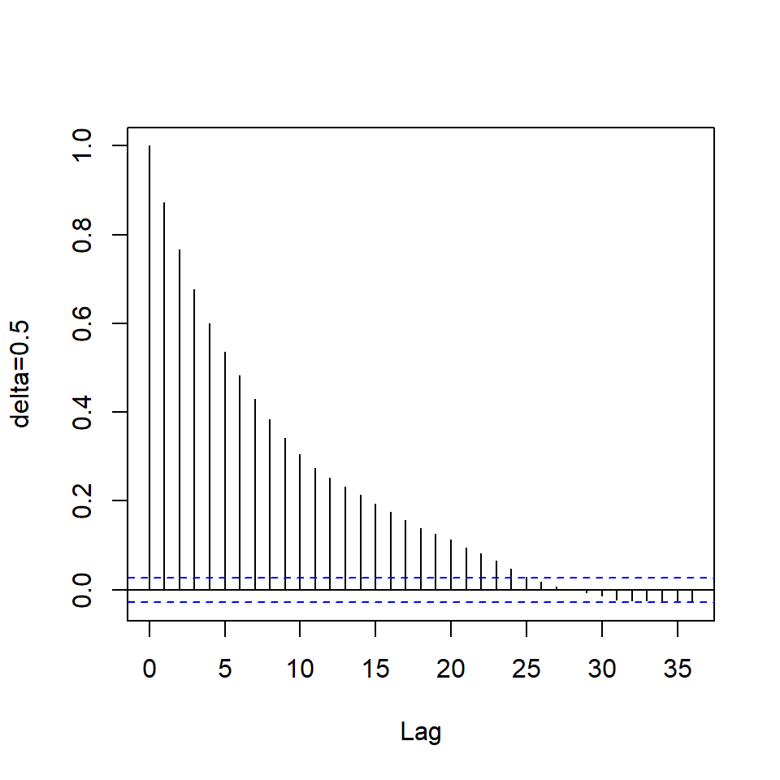

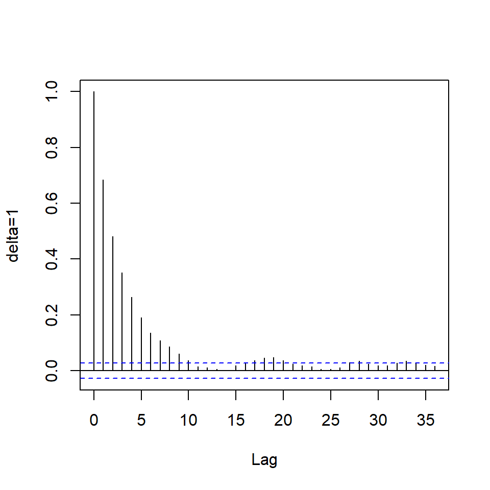

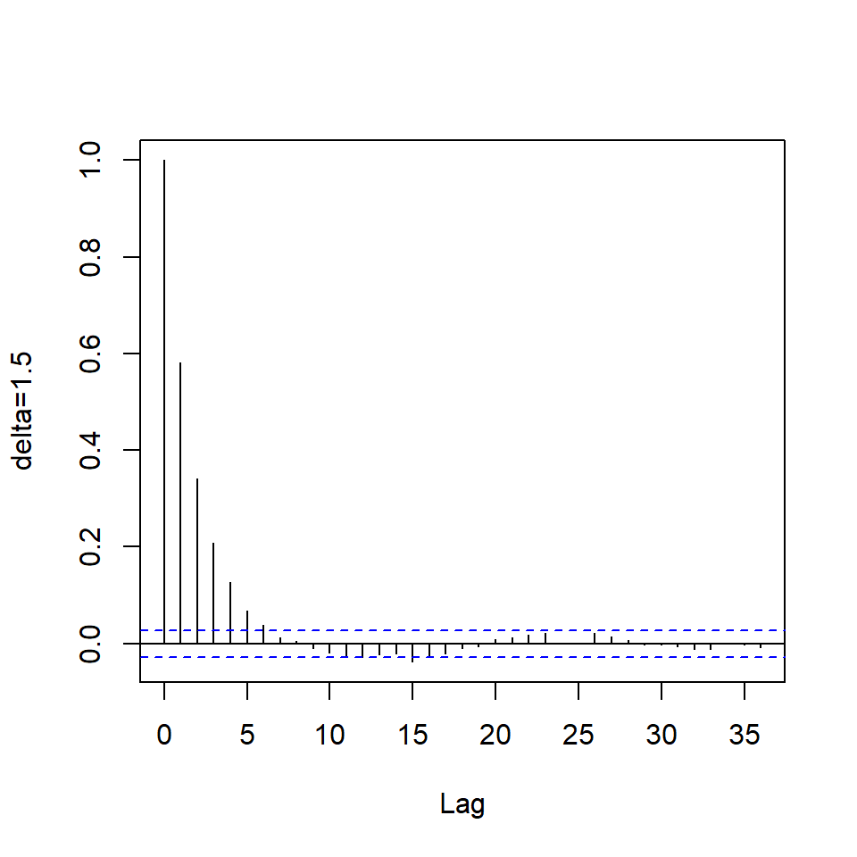

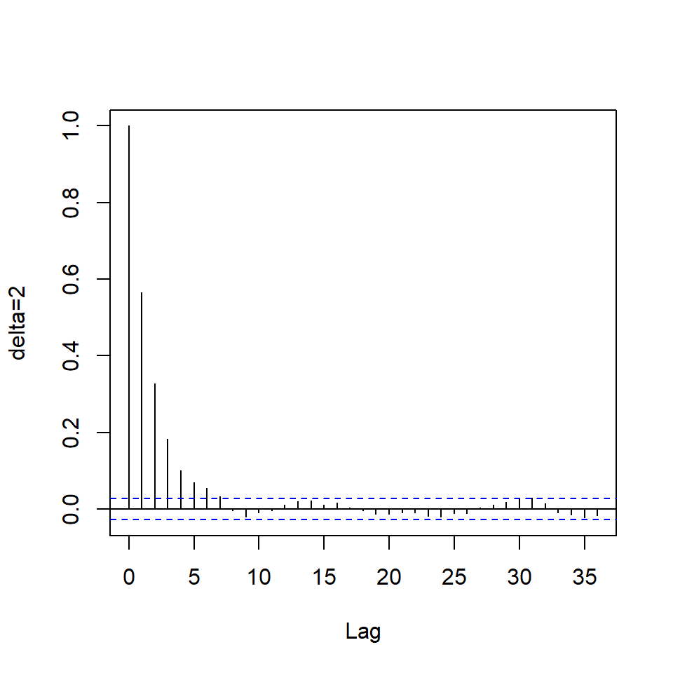

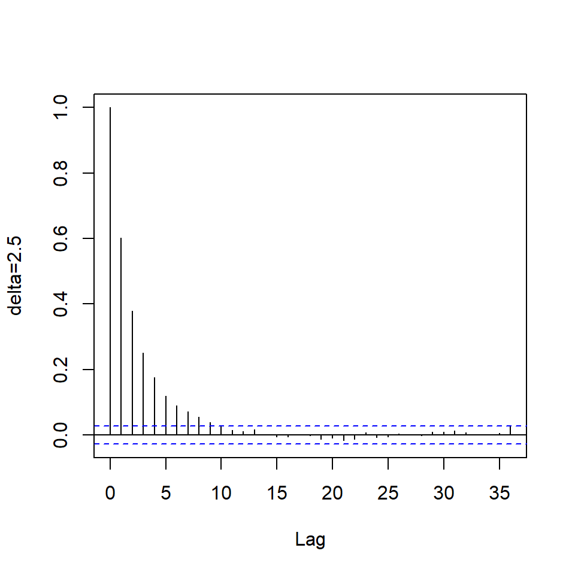

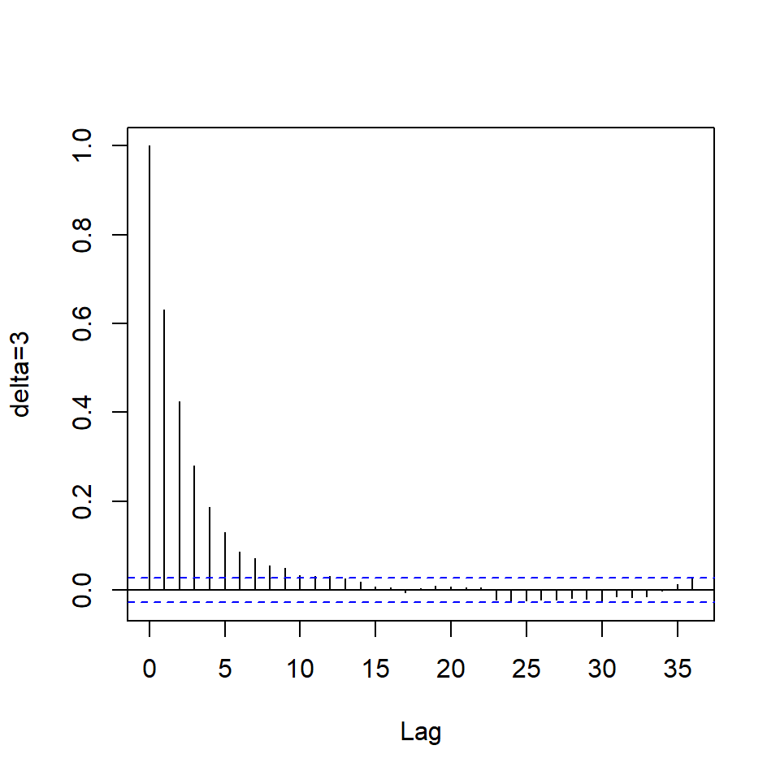

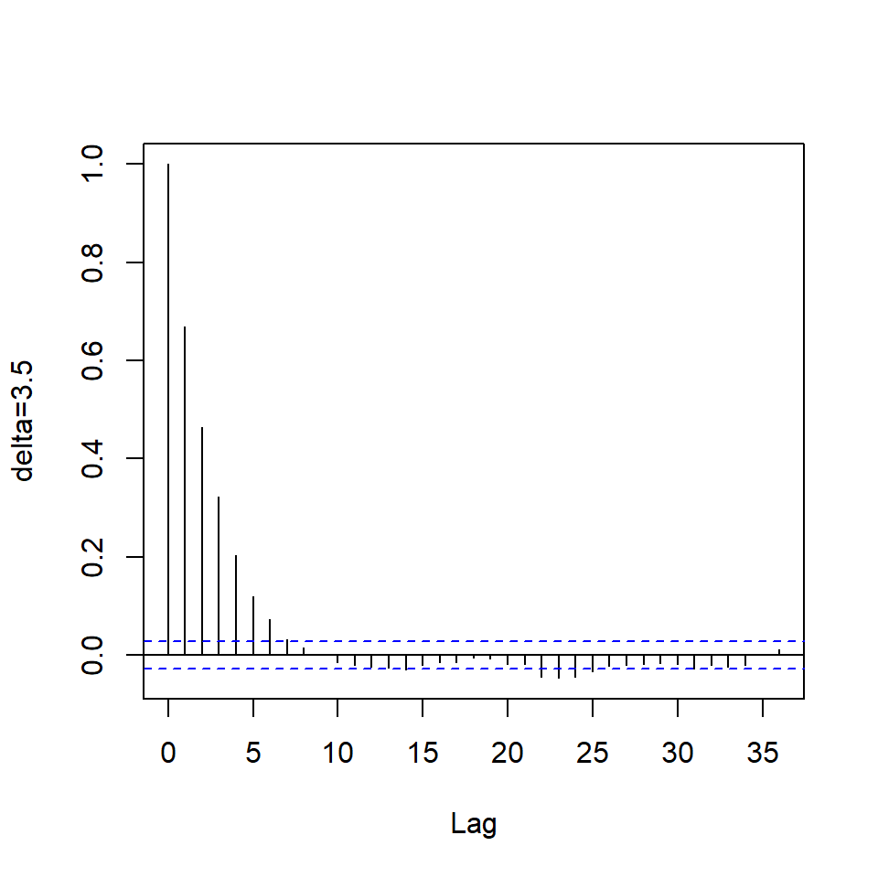

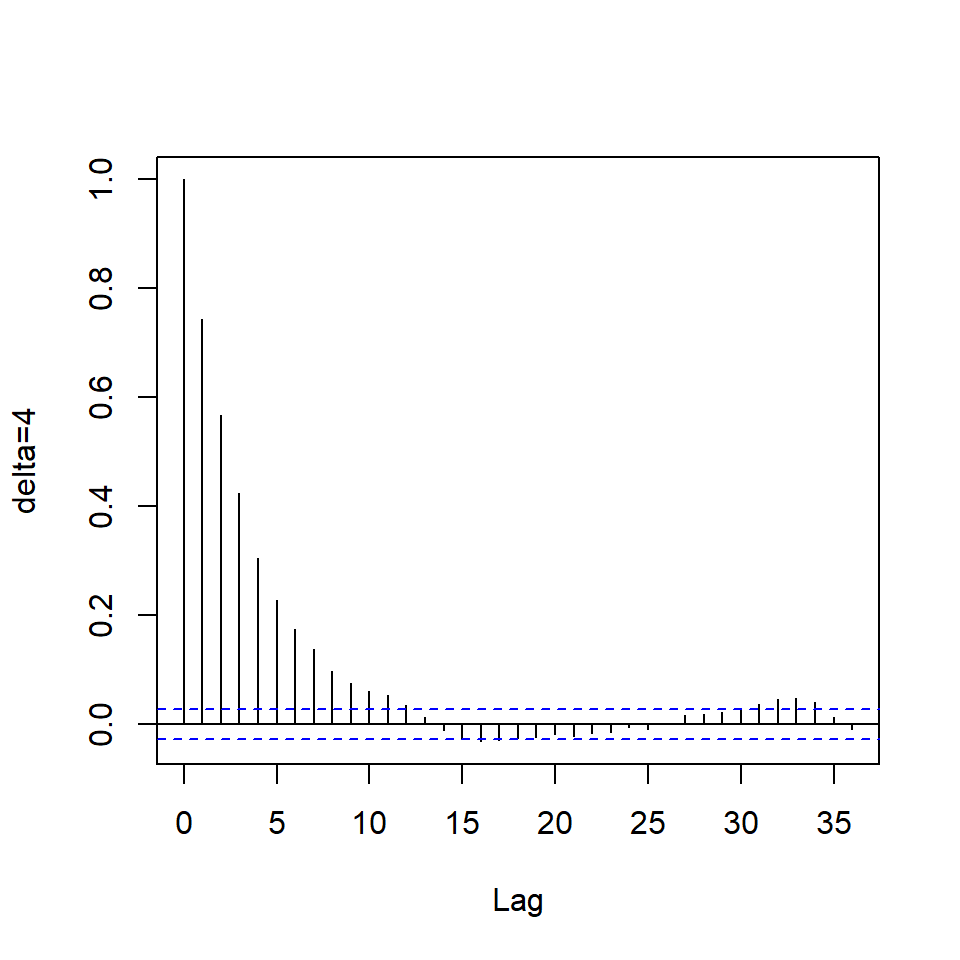

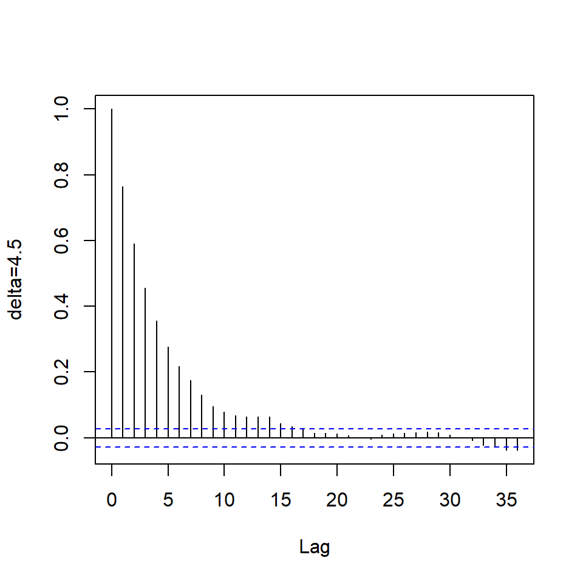

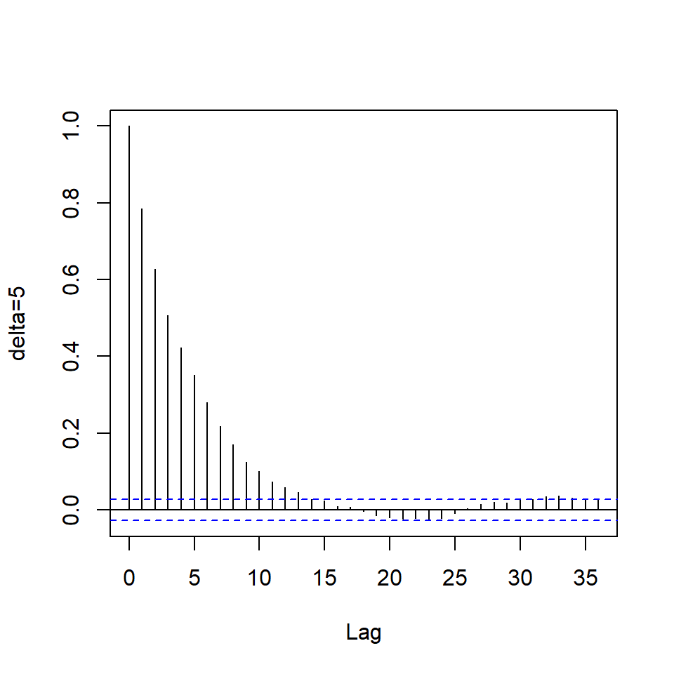

```r
#par(mfrow=c(5,2))
for(i in 1:length(deltas))
  acf(simluations2[,i], ylab=paste0("delta=",deltas[i]), main="")
```

## Use Cauchy and Laplace candidates

We generalize a little bit the Metropolis-Hastings algorithm in order to accept generic distributions as proposal: we’ll allow to pass a generator into the M-H function:

```r
#distr_sim -> like rnorm, rcauchy etc...
metro_hastings_randomwalk = function(nsim, distr_sim){
  x = rep(0, nsim)

  #Let initlialization value be 0.

  acc_values = 1

  for(s in 2:nsim){
    proposal = x[s-1] + distr_sim(1)
    accept_prob = min(1, exp((x[s-1]^2-proposal^2)/2))
    u = runif(1)
    if(u<accept_prob){
      acc_values = acc_values + 1
      x[s] = proposal
    }else{
      x[s] = x[s-1]
    }
  }

  acc_rate = acc_values/nsim

  return(list(x=x, acc_rate=acc_rate))
}
```

We can then proceed to simulations:

```r
set.seed(100)
chain_cauchy = metro_hastings_randomwalk(nsim, rcauchy)
chain_laplace = metro_hastings_randomwalk(nsim, rmutil::rlaplace)
```

We may then plot the traceplot and the histograms:

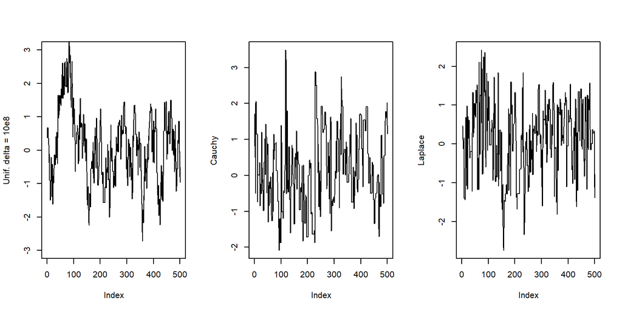

```r
par(mfrow=c(1,3))

#traceplots - only last 500 iterations (like in book)
plot(simulations[[2]]$x[4500:5000], type='l', ylab = paste0("Unif. delta = 10e",i-2), ylim=c(-3,3))
plot(chain_cauchy$x[4500:5000], type='l', ylab = "Cauchy")
plot(chain_laplace$x[4500:5000], type='l', ylab = "Laplace")
```

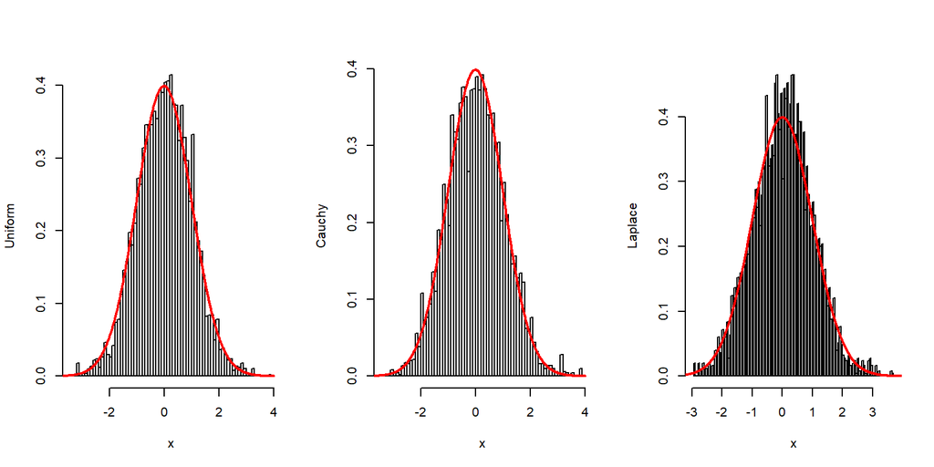

```r
par(mfrow=c(1,3))

#histograms

hist(simulations[[2]]$x, breaks=100, main="", probability = T, ylab = paste0("Uniform"), xlab = "x")
lines(seq(-4,4, by=0.01), dnorm(seq(-4,4, by=0.01)),type="l", col="red", lwd=2)

hist(chain_cauchy$x, breaks=100, main="", probability = T, ylab = paste0("Cauchy"), xlab = "x")
lines(seq(-4,4, by=0.01), dnorm(seq(-4,4, by=0.01)),type="l", col="red", lwd=2)

hist(chain_laplace$x, breaks=100, main="", probability = T, ylab = paste0("Laplace"), xlab = "x")
lines(seq(-4,4, by=0.01), dnorm(seq(-4,4, by=0.01)),type="l", col="red", lwd=2)
```

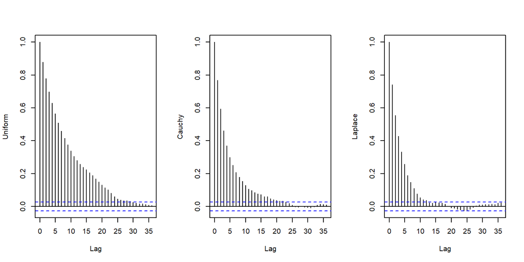

```r
par(mfrow=c(1,3))

#autocorrelation
acf(simulations[[2]]$x, ylab = "Uniform", main ="")
acf(chain_cauchy$x, ylab = "Cauchy", main="")
acf(chain_laplace$x, ylab = "Laplace", main="")
```

What we can immediately see is that all three chains show good fit, and all of them show sings of convergence. From the traceplots, all three chains show a good dose of exploration of the space, albeit the Laplace histogram is maybe a bit too concentrated around 0 with spikes too high. In terms of autocorrelation, the Laplace chain seems to fare much better than the other two.

Let us have a look at the acceptance rate:

```r
print(simulations[[2]]$acc_rate)
```

```
## [1] 0.8182
```

```r
print(chain_cauchy$acc_rate)
```

```
## [1] 0.5424
```

```r
print(chain_laplace$acc_rate)
```

```
## [1] 0.682
```

In order to lower it, we must play with the parameters (note that we explore for different ranges of parameter which were found to be optimal for previous tries):

```r
set.seed(1)
chains_unif = list()
chains_cauchy = list()
chains_laplace = list()
acc_rates = matrix(NA,nrow=50,ncol=3)



for(i in 1:50){
  ## delta ranges from .2 to 10.0
  chains_unif[[i]] = metro_hastings_N_unif(nsim, i/5)
  acc_rates[i,1] = chains_unif[[i]]$acc_rate

  ##scale for cauchy ranges from .1 to 5.0
  chains_cauchy[[i]] = metro_hastings_randomwalk(nsim, function(x) rcauchy(x,scale=i/10))
  acc_rates[i,2] = chains_cauchy[[i]]$acc_rate

  ##s for laplace ranges from .2 to 10.0
  chains_laplace[[i]] = metro_hastings_randomwalk(nsim, function(x) rmutil::rlaplace(x,s=i/5))
  acc_rates[i,3] = chains_laplace[[i]]$acc_rate
}

acc_rates
```

```
##         [,1]   [,2]   [,3]
##  [1,] 0.9594 0.8938 0.9358
##  [2,] 0.9224 0.8272 0.8440
##  [3,] 0.8830 0.7706 0.7768
##  [4,] 0.8432 0.7312 0.7272
##  [5,] 0.8066 0.6720 0.6570
##  [6,] 0.7704 0.6584 0.6288
##  [7,] 0.7286 0.6210 0.5804
##  [8,] 0.6932 0.5990 0.5326
##  [9,] 0.6764 0.5560 0.4988
## [10,] 0.6408 0.5390 0.4734
## [11,] 0.5856 0.5154 0.4692
## [12,] 0.5778 0.4866 0.4354
## [13,] 0.5546 0.4688 0.4024
## [14,] 0.5166 0.4566 0.3766
```

[output cut: 36 more lines]

We see that optimal values are reached when:

- $\delta$ for the uniform is equal to 6.4 (index of iteration 32)
- the dispersion parameter for the Cauchy is 3.3 (index of iteration 33)
- the dispersion parameter for the Laplace is 5.2 (index of iteration 26)

Next, we can plot our optimal chains as far as acceptance rate is concerned:

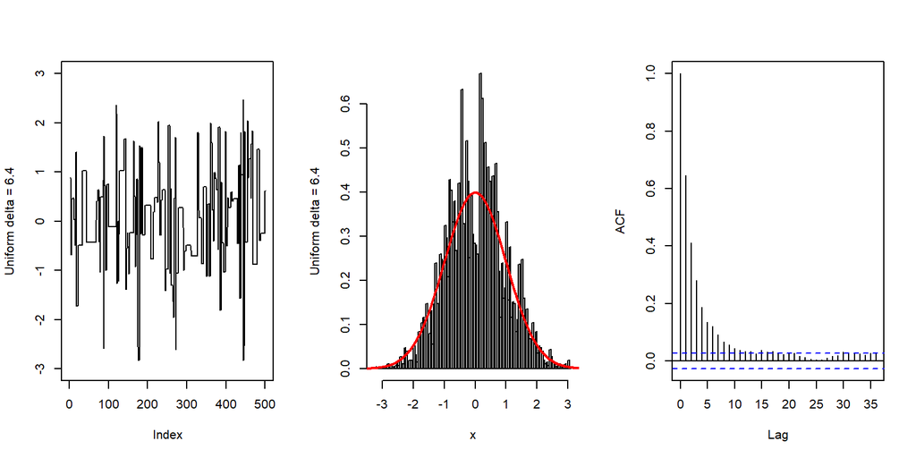

```r
par(mfrow=c(1,3))
#traceplot
plot(chains_unif[[32]]$x[4500:5000], type='l', ylab = paste0("Uniform delta = 6.4"), ylim=c(-3,3))

#histogram
hist(chains_unif[[32]]$x, breaks=100, main="", probability = T, ylab = paste0("Uniform delta = 6.4"), xlab = "x")
lines(seq(-4,4, by=0.01), dnorm(seq(-4,4, by=0.01)),type="l", col="red", lwd=2)

#acf
acf(chains_unif[[32]]$x, main="")
```

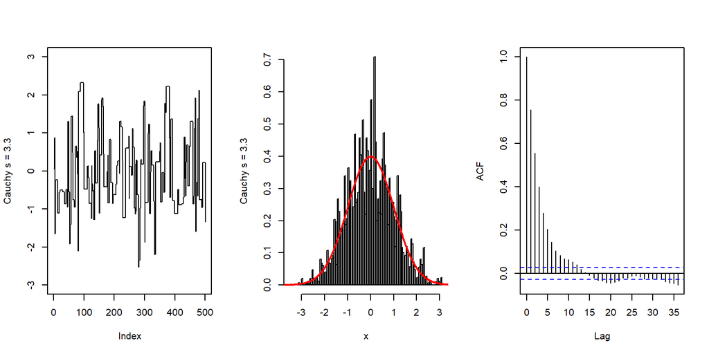

```r
par(mfrow=c(1,3))

plot(chains_cauchy[[33]]$x[4500:5000], type='l', ylab = paste0("Cauchy s = 3.3"), ylim=c(-3,3))

hist(chains_cauchy[[33]]$x, breaks=100, main="", probability = T, ylab = paste0("Cauchy s = 3.3"), xlab = "x")
lines(seq(-4,4, by=0.01), dnorm(seq(-4,4, by=0.01)),type="l", col="red", lwd=2)

acf(chains_cauchy[[33]]$x, main="")
```

[figure not shown]

```r
par(mfrow=c(1,3))

plot(chains_laplace[[26]]$x[4500:5000], type='l', ylab = paste0("Cauchy s = 3.4"), ylim=c(-3,3))

hist(chains_laplace[[26]]$x, breaks=100, main="", probability = T, ylab = paste0("Cauchy s = 3.4"), xlab = "x")
lines(seq(-4,4, by=0.01), dnorm(seq(-4,4, by=0.01)),type="l", col="red", lwd=2)

acf(chains_laplace[[26]]$x, main="")
```

We note that those choices nor show a good fit to the $N(0,1)$ distribution, neither seem perfect in terms of autocorrelation:

- the Uniform one has a $\delta$ close to the optimal one we found before
- the Cauchy one fares much better than its *vanilla* form
- the Laplace one has a worse result than before, showing a spike for a lag around 20-25